# Module 3: Supplamentary Material

MATH1318 Time Series Analysis

Dr. Haydar Demirhan

# Introduction

This supplementary material is preapred to clarify the following contents:

- Autocorrelation function (ACF) and ACF plot,
- Partial autocorrelation function and PACF plot,
- Autoregressive and moving average patterns in time series.

# Autocorrelation function (ACF) and ACF plot

ACF measures the correlation between two occurences of the same time series $\{Y_{t}, t=1,2\dots,n\}$. $ACF(k)$ is the correlation between points separated by $k$ time points, namely $Corr(Y_{t},Y_{t+k})$. So $ACF(1)$ is the correlation between successive time points. $ACF(2)$ is the correlation between a time point and another one two time steps ahead. $ACF(3)$ is the correlation between a time point and the other time point three steps ahead, and so on.

Let’s assume that we have the following ACF:

ACF(1) = 0.98

ACF(2) = 0.88

ACF(3) = 0.84

ACF(4) = 0.82

ACF(5) = 0.79

…

The points corresponding to ACF(1), ACF(2), and ACF(3) values are shown in the following display:

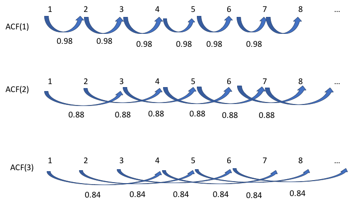

When the distance between considered points is increased, the correlation between those points decreases.

In the sample ACF plot, each of $ACF(k)$ values is shown by a line as shown in the figure below:

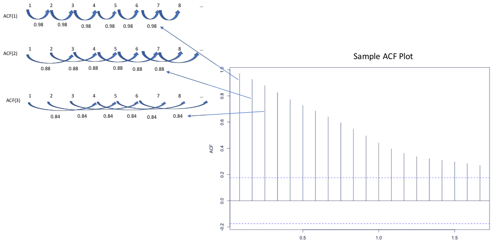

When we estimate the values of $ACF(k)$ from the time series of interest, we get the sample ACF.

# Partial autocorrelation function and PACF plot

When the indirect effects of intervening time points in autocorrelation function is removed, we get the partial autocorrelation function (PACF). Think like that, when we try to find the correlation between the first and third time poinst, namely $t_{1}$ and $t_{3}$, because $t_{1}$ is correlated with $t_{2}$ and $t_{2}$ is correlated with $t_{3}$, $t_{2}$ has an intervention effect on the correlation between series at $t_{1}$ and $t_{3}$. In the PACF, this intervention effect is removed and we get a more crisp infromation about the pure correlation between $t_{1}$ and $t_{3}$. This is illustrated over the $PACF(2)$, say it is 0.7, in the following figure:

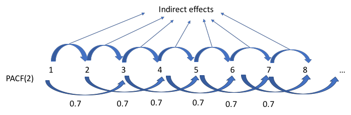

The first point is directly correlated with the second point and the second point is directly correlated with the third point. So the correlation between the first and the third point is under the effect of their correlation structure with the second point. PACF removes the effect of the correlation structure between the first and second and the second and third points while looking for the correlation between the first and third points. This is the same for further time points.

The sample PACF plot include a line for each estimate of $PACF(k)$ form the sample. That’s why we call it *sample* PACF.

Notice that because there is no intervenning time points in the calculation of one time point ahead autocorrelation $ACF(1)$ and partial autocorrelation $PACF(1)$ are equal to each other, $ACF(1)=PACF(1)$.

# Autoregressive and moving average patterns in time series

In most of the time series applications, there is no additional predictor at hand. We only have information arising from the serieal correlation in the series of interest. Autoregression is simply fitting a simple linear regression to the series $\{Y_{t}\}$ on itself to use that autocorrelation to model the data. A simple autoregression or **autoregressive** model is

$$Y_{t} = \beta_{0} + \beta_{1}Y_{t-1}+\epsilon_{t}$$

where $\epsilon_{t}\sim N(0,\sigma^{2}_{\epsilon})$. Here we make use of serial correlation to explain $Y_{t}$.

Connecting back to the existence of successive points in the time series plot, when we have successive observations in the time series plot, it means that consecutive observations inform each other forwardly as in the autoregressive model above. Therefore, we conclude that there is an autoregressive behaviour in the series.

For the moving average behaviour, because we calculate average of $k$ observations with a given time window of length $k$ and move the time window forward, the points in the time series plot fluctuates around the mean level rather than successively following each other as in the autoregressive patterns. That’s why we suspect existence of a moving average bahaviour in the series when we observe fluctuating pattern around a mean level in the series.

# References

- Cryer, J.D., Chan, K.S. (2008). Time Series Analysis With Applications in R, Springer.
- Hyndman, R.J., Koehler, A.B., Ord, J.K., and Snyder, R.D. (2008). [Forecasting with exponential smoothing: the state space approach](http://www.exponentialsmoothing.net), Springer-Verlag.